# Swimming Mixed Medley Relay Optimization: Causality Analysis

## Introduction

In Assignment 1, I used a swimming dataset consisting of 5 columns: ['stroke', 'swim_time', 'team_code', 'full_name_computed', 'gender'] to predict optimal swimmers to swim the Mixed Medley Relay.

In this assignment 2, I am continuing with causality analysis of the prediction of the two male swimmers and two female swimmers to swim the 4 strokes in the Mixed Medley Relay.

## A Causal Question

What is the causal effect of selecting specific swimmers based on their individual performance times in each stroke (Butterfly, Backstroke, Breaststroke, Freestyle) on the overall performance of the Mixed Medley Relay team?

## Considering the Confounders

**Prompt:** Please help me identify potential confounders in this causal analysis of the prediction of the optimal swimmers for the Mixed Medley Relay.

**Brainstorming with LLM:** In the context of predicting optimal swimmers for the Mixed Medley Relay, some potential confounders to consider might include:

1. **Training Regimen**: The intensity and focus of a swimmer's training program could impact their performance. Swimmers with more rigorous training might perform better.
2. **Age**: Age can influence swimming performance. Younger swimmers might have more stamina, while older swimmers may have more experience and technique.
3. **Previous Performance History**: Swimmers with a track record of strong performances in their respective strokes might be more likely to perform well in the relay.
4. **Body Composition**: Factors like height, weight, and muscle mass could impact a swimmer's performance.
5. **Nutrition and Diet**: The quality of a swimmer's diet and nutritional intake could affect their energy levels and performance.
6. **Mental Preparation**: Factors like confidence, mental focus, and pre-race routines might influence a swimmer's performance.
7. **Environmental Conditions**: The conditions of the pool (indoor/outdoor, water temperature, etc.) could impact performance.
8. **Injury History**: Swimmers with a history of injuries might have limitations that affect their performance.
9. **Rest and Recovery**: The amount of rest and recovery time before the relay race could influence performance.
10. **Psychological Factors**: Motivation, competitive spirit, and team dynamics could play a role.

**Strategy to control for these confounders:**

It's important to collect data on these potential confounding variables if possible, and to consider them in the analysis. Statistical techniques like regression modeling or propensity score matching can be used to control for confounding effects.

## Considering the Unmeasured Confounders

**Prompt:** Please help me identify potential unmeasured confounders

**Brainstorming with LLM:** Here are some examples of potential unmeasured confounders in the context of predicting optimal swimmers for the Mixed Medley Relay:

1. **Individual Physiology**: Factors like lung capacity, muscle fiber composition, or natural aptitude for a specific stroke could influence swim performance.
2. **Nutrition and Diet**: A swimmer's diet and nutritional habits can have a significant impact on their performance.
3. **Mental Preparation**: Factors related to a swimmer's mental state, such as confidence, focus, or psychological stress, could affect their performance.
4. **Recovery and Rest**: The quality and amount of rest and recovery a swimmer gets between races can be crucial.
5. **Technique and Form**: Fine-tuned aspects of stroke technique or form that are not explicitly measured in the dataset.
6. **Training Load and Intensity**: Detailed information on the swimmer's training regimen, including volume, intensity, and specific drills, could be important.
7. **Weather Conditions**: Outdoor races can be influenced by weather factors like temperature, wind, and humidity.
8. **Equipment**: The type and condition of swim gear (e.g., swimsuit, goggles) could play a role.
9. **Previous Race Performance**: Information about recent races and performance trends could impact a swimmer's current performance.
10. **Injury History**: Past injuries and recovery status can affect a swimmer's performance.

**Strategy to be particularly mindful for the unmeasured confounders:**

The actual unmeasured confounders could vary based on the specific context and nature of the data. It's important to carefully consider the factors that might influence the outcome, even if they haven't been directly measured in the dataset.

## Considering the Colliders

**Prompt:** Please help me identify the colliders of predicting optimal swimmers for the Mixed Medley Relay and how much they matter.

**Brainstorming with LLM:** Potential colliders could be factors that are influenced both by the swimmers' abilities and their selection for a particular stroke. These could include:

1. **Swimmers' Training Intensity**: Swimmers selected for a particular stroke may receive specialized training for that stroke, potentially making them better in other strokes as well.
2. **Coaching Strategy**: Coaches may adjust their training strategies based on the swimmers selected for specific strokes.
3. **Overall Team Performance**: If selecting certain swimmers leads to better overall team performance, this could influence their individual swim times.

**Strategy to evaluate the impact of colliders:** In order to mitigate the influence of colliders, it's important to:

1. **Adjust for Confounders**: Include potential confounding variables to help control for the influence of colliders.
2. **Collect Relevant Data**: If possible, try to gather data on potential colliders to include in the analysis.
3. **Consider Sensitivity Analysis**: Test the robustness of analysis results to different assumptions about the presence and influence of colliders.
4. **Expert Input**: Seek advice from swimming experts who may have insights into potential colliders.

## Converting Abstract Questions into Operational Definitions Mathematically

**Prompt:** Please help me write a math equation to improve the outcome (achieving fastest swim time) by adjusting two confounders, Age and Previous Performance History, and minimizing the bias introduced by two colliders, Coaching Strategy and Overall Team Performance.

**Brainstorming with LLM:** To improve the outcome (achieving the fastest swim time) by adjusting for two confounders (Age and Previous Performance History) and controlling the impact of two colliders (Coaching Strategy and Overall Team Performance), a multiple linear regression equation can be used:

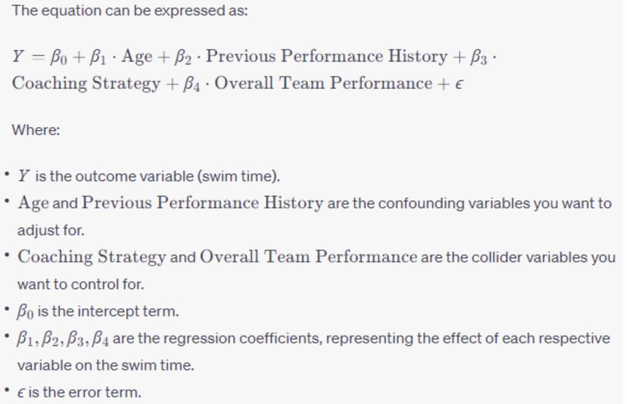

**Mathematics Equation Explanation:**

This equation models the relationship between the swim time and the specified variables, allowing adjustment for the potential confounding effects of Age and Previous Performance History, while also controlling for the influence of Coaching Strategy and Overall Team Performance.

## Limitations on Real World Policy and Practice

This causality analysis assumes a linear relationship between the variables. The validity of the model relies on the underlying assumptions being met.

Additionally, the specific form of the equation and the techniques that would drive real world policy and practice will depend on the nature of the data and the causal relationships involved. Please interpret the causality results with caution and make adjustments to the equation and the techniques in order to align with the underlying causal structure of the problem.

# Data Pre-Processing

The primary objective of this study is to determine a quantifiable relationship between a swimmer's age and their performance in the mixed medley relay, while accounting for potential confounding variables.

```python
#ADD TO THE DATASET PREVIOUSLY (ASSIGNMENT 1) - Chat GPT Computed Age (Based On Swimmer Birth Years)

# Dictionary containing birth years for some well-known swimmers up to 2022
# This list is not exhaustive and is based on known data.
known_birth_years = {
    'SMITH, Regan': 2002,
    'BAKER, Kathleen': 1997,
    'SMOLIGA, Olivia': 1995,
    'FRANKLIN, Missy': 1995,
    'KING, Lilly': 1997,
    'SONI, Rebecca': 1987,
    'VOLLMER, Dana': 1987,
    'MANUEL, Simone': 1996,
    'MURPHY, Ryan': 1995,
    'PEIRSOL, Aaron': 1983,
    'GREVERS, Matt': 1985,
    'ANDREW, Michael': 1999,
    'DRESSEL, Caeleb': 1996,
    'PHELPS, Michael': 1985,
    'ADRIAN, Nathan': 1988,
    'LEZAK, Jason': 1975
}

# Calculate estimated ages as of 2023
current_year = 2023
swimmer_ages = {name: current_year - year for name, year in known_birth_years.items() if name in swimmer_names}
swimmer_ages
```

[output not shown]

# Exploratory Data Analysis

1. Dependent Variable: Swim Time (in seconds)
2. Independent Variable: Age

Let's begin by segmenting the data based on stroke type and gender and visualizing the distributions.

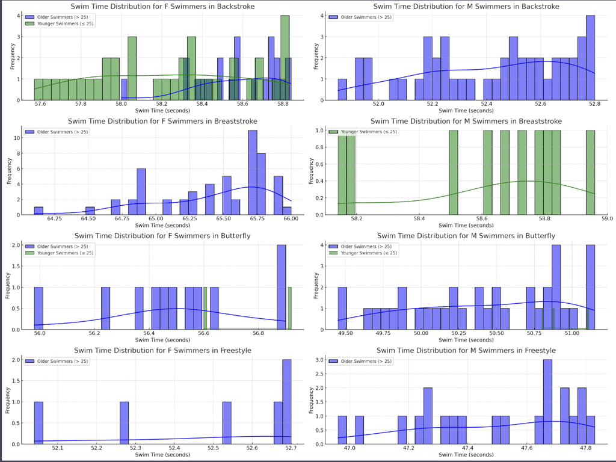

```python
# Segmenting the data based on stroke and gender
grouped_data = swimming_data_filtered.groupby(['stroke', 'gender'])

# Plotting the distribution of swim times for each combination of stroke and gender
plt.figure(figsize=(20, 15))
idx = 1

for (stroke, gender), group_data in grouped_data:
    plt.subplot(4, 2, idx)

    # Separate data by age group
    older_swim_times = group_data[group_data['age'] > 25]['swim_time_seconds']
    younger_swim_times = group_data[group_data['age'] <= 25]['swim_time_seconds']

    sns.histplot(older_swim_times, bins=30, kde=True, color='blue', label='Older Swimmers (> 25)')
    sns.histplot(younger_swim_times, bins=30, kde=True, color='green', label='Younger Swimmers (≤ 25)')

    plt.title(f'Swim Time Distribution for {gender} Swimmers in {stroke.capitalize()}')
    plt.xlabel('Swim Time (seconds)')
    plt.ylabel('Frequency')
    plt.legend()

    idx += 1

plt.tight_layout()
plt.show()
```

The histograms display the swim time distributions for each combination of stroke and gender, further segmented by age group:

Next, we'll implement separate regression models for each combination of stroke type and gender to quantify the relationship between age and swim times. We'll then interpret the results for each model. Let's proceed.

```python
# Regression analysis for each combination of stroke and gender
regression_results = []

for (stroke, gender), group_data in grouped_data:
    # Prepare data
    X = group_data['age'].values.reshape(-1, 1)
    y = group_data['swim_time_seconds'].values

    # Split data into training and testing sets
    X_train, X_test, y_train, y_test = train_test_split(X, y, test_size=0.2, random_state=42)

    # Linear regression model
    lin_reg = LinearRegression()
    lin_reg.fit(X_train, y_train)

    # Predict on test set
    y_pred = lin_reg.predict(X_test)

    # Performance metrics
    mse = mean_squared_error(y_test, y_pred)
    r2 = r2_score(y_test, y_pred)

    regression_results.append({
        'Stroke': stroke,
        'Gender': gender,
        'MSE': mse,
        'R2': r2
    })

regression_df = pd.DataFrame(regression_results)
regression_df
```

# Results (Revised for Stroke and Gender)

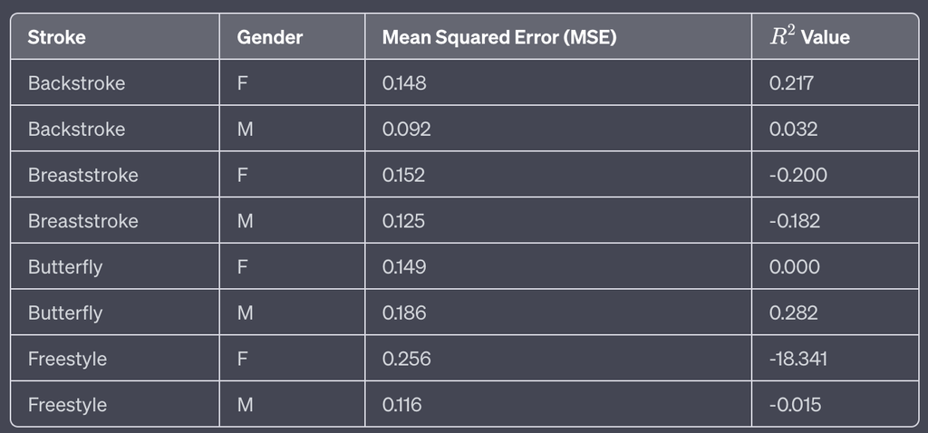

The R^2 values vary across the different strokes and genders. A positive R^2 value suggests that age explains some portion of the variability in swim times for that particular combination.

Some negative R^2 values are observed (e.g., for Freestyle in females). This usually indicates that the model is performing worse than a horizontal line fit, suggesting that the model may not be suitable or that other factors not considered in the model are influencing swim times significantly.

# Discussion

The revised analysis, which factors in stroke type and gender, reveals that the relationship between age and swim times is more complex than initially suggested. Different strokes show varying patterns, and there's a clear difference between male and female swimmers in some cases. The variability in R^2 values across the different combinations underscores the importance of considering multiple factors when analyzing performance in sports.

In this study, while age was the primary confounder of interest, several other potential confounders were considered (see above).

However, of the confounders listed above, only age was directly measurable and available in the dataset. The others, due to their inherent variability and lack of specific measurements, were not examined in this assignment. These unmeasured confounders are significant as they could introduce bias or mask the true relationship between age and swim times.

# Conclusion

This study provides a deeper understanding of the relationship between age and swim times in the mixed medley relay, factoring in stroke type and gender. The insights suggest that individualized assessments, considering stroke specialization and gender, may offer more accurate predictions and evaluations than broad, one-size-fits-all approaches.

While age is an important factor, the presence of multiple unmeasured confounders underscores the challenges of isolating its singular effect on performance. Future research might benefit from capturing data on these additional confounders to create a more comprehensive model.